# The `dplyr` package

# 1 Learning Objectives

1. Understand conceptually what each `dplyr` verb does
2. Be able to use `dplyr` verbs (`filter`, `arrange`, `select`, `mutate`, `summarise`) to extract a required dataset
3. Be able to deal with missing values and nulls whilst using functions
4. Know about - and be able to use - additional functions that support the `dplyr` verbs - `group_by`, helper functions, window functions and logical operators
5. Be familiar with and able to use the magrittr operator (pipe) to chain together commands

**Duration - 1 hour**

# 2 Data wrangling

> “Data wrangling is the process of transforming and mapping data from one”raw" data form into another format with the intent of making it more appropriate and valuable for a variety of downstream purposes such as analytics. - Wikipedia"

Typically, wrangling data involves taking a dataset, selecting columns you want, filtering rows you want, arranging data by a certain order, adding columns you want, grouping data, and eventually summarising the data you have.

And while this may seem like a less exciting part of data analysis, it is without a doubt, the part of your data analysis process you’ll spend the most time on. In fact, it is said that 80% of a data scientist’s job is cleaning and wrangling data.

[figure not shown]

# 3 Enter… `dplyr`

[figure not shown]

`dplyr` is a package from the tidyverse created for ‘data wrangling’. Given the vast amount of time analysts spend wrangling data, the aim of the dplyr package is to provide you will all the tools you need to do this, in one handy package. Each `dplyr` function is known as a **verb**, and `dplyr` aims to provide a function for each basic verb of data manipulation. As a bonus, the verbs (aka functions) have been given names that actually reflect what they do.

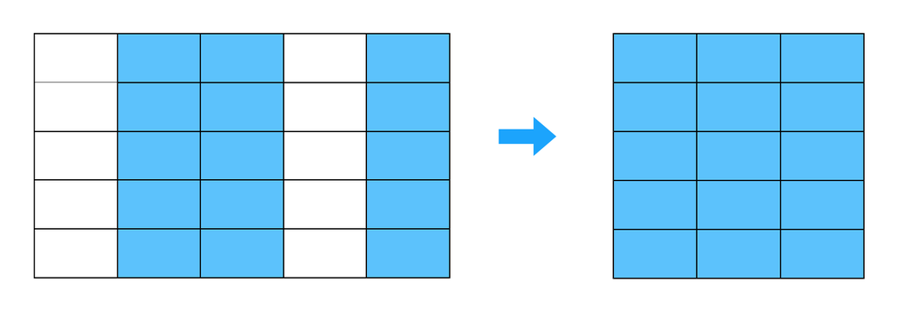

**`select()` Include or exclude certain variables (columns)**

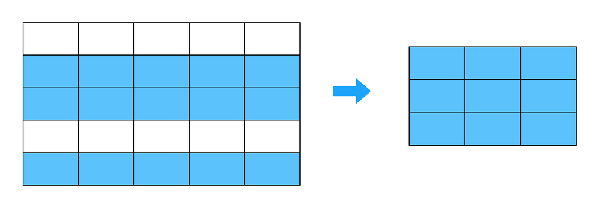

**`filter()` Include or exclude certain observations (rows)**

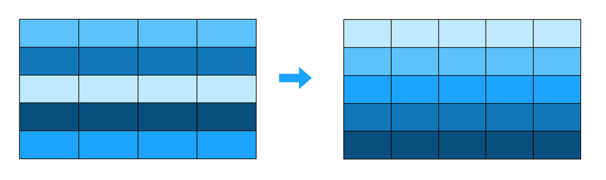

**`arrange()` Change the order of observations (rows)**  
***

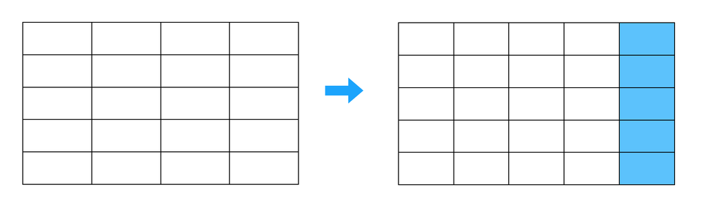

**`mutate()` Create new variables (columns)**

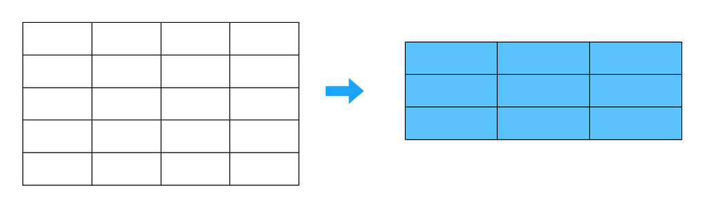

**`summarise()` Derive aggregate variables for groups of observations**

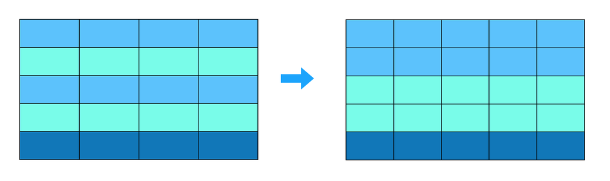

**`group_by()` Create groups of observations**

These six functions are known as ’single table verbs’ because they only operate on one table at a time. Later in the course you will learn two-table verbs that you can use to merge tables together. Although the operations of these functions may seem very simplistic, it’s amazing what you can accomplish when you string them together: Hadley Wickham has claimed that 90% of data analysis can be reduced to the operations described by these six functions.

# 4 Working with `dplyr`

To demonstrate the power of the six dplyr verbs, we will use them to work with the [game of thrones](https://www.kaggle.com/mylesoneill/game-of-thrones/downloads/game-of-thrones.zip/1) dataset downloaded from the open data source website kaggle.

First, let’s load in the tidyverse packages we need. Don’t forget, we need to run this code chunk for it to take effect: just writing the code is not enough.

```r
library(tidyverse)
```

Next, let’s have a look at the dataset. [You can find out all about the variables and coding you expect here](https://www.kaggle.com/mylesoneill/game-of-thrones#character-deaths.csv)

The first thing we want to do is load our data into R. For this, we’re going to use a function. For this, we will use the `read_csv` function from the `dplyr` package. Type the following:

```r
all_deaths <- read_csv("data/character-deaths.csv")
```

Note that as you typed the command above, RStudio tries to help you, offering possible completions which you can select by pressing tab.

Let’s break down what this line of code does. It says ‘use the `read_csv()` function to read the contents of `character-deaths.csv`, and store the data in a variable called `all_deaths`. A variable provides us with named storage that our programs can manipulate.

You can quickly check if you’ve got loaded data by looking in your RStudio environment. In most RStudio desktop configurations, this is in the top right hand corner of the screen. If you see anything under the Data heading, it means you’ve got loaded data.

# 5 Checking our data

The first step when working with data is to check what you have. After all, if you don’t really understand what data you have, you won’t be able to make sense of any summaries, graphs or statistics you produce. We can do this in a few different ways.

To start with, we can check the size of our data, and the names of our columns.

```r
# number of rows
nrow(all_deaths)
```

```
## [1] 917
```

```r
# number of observations
ncol(all_deaths)
```

```
## [1] 13
```

```r
# overall dimensions
dim(all_deaths)
```

```
## [1] 917  13
```

```r
# variable names
names(all_deaths)
```

```
##  [1] "name"               "allegiances"        "year_of_death"
##  [4] "book_of_death"      "death_chapter"      "book_intro_chapter"
##  [7] "gender"             "nobility"           "book1_GoT"
## [10] "book2_CoK"          "book3_SoS"          "book4_FfC"
## [13] "book5_DwD"
```

```r
# check the first 10 rows
head(all_deaths, 10)
```

| name | allegiances | year_of_death | book_of_death | death_chapter | book_intro_chapter | gender | nobility | book1_GoT | book2_CoK | book3_SoS | book4_FfC | book5_DwD |
| --- | --- | --- | --- | --- | --- | --- | --- | --- | --- | --- | --- | --- |
| Addam Marbrand | Lannister | NA | NA | NA | 56 | 1 | 1 | 1 | 1 | 1 | 1 | 0 |
| Aegon Frey (Jinglebell) | None | 299 | 3 | 51 | 49 | 1 | 1 | 0 | 0 | 1 | 0 | 0 |
| Aegon Targaryen | House Targaryen | NA | NA | NA | 5 | 1 | 1 | 0 | 0 | 0 | 0 | 1 |
| Adrack Humble | House Greyjoy | 300 | 5 | 20 | 20 | 1 | 1 | 0 | 0 | 0 | 0 | 1 |
| Aemon Costayne | Lannister | NA | NA | NA | NA | 1 | 1 | 0 | 0 | 1 | 0 | 0 |
| Aemon Estermont | Baratheon | NA | NA | NA | NA | 1 | 1 | 0 | 1 | 1 | 0 | 0 |
| Aemon Targaryen (son of Maekar I) | Night's Watch | 300 | 4 | 35 | 21 | 1 | 1 | 1 | 0 | 1 | 1 | 0 |
| Aenys Frey | None | 300 | 5 | NA | 59 | 0 | 1 | 1 | 1 | 1 | 0 | 1 |
| Aeron Greyjoy | House Greyjoy | NA | NA | NA | 11 | 1 | 1 | 0 | 1 | 0 | 1 | 0 |
| Aethan | Night's Watch | NA | NA | NA | 0 | 1 | 0 | 0 | 0 | 1 | 0 | 0 |

```r
# check the last 10 rows
tail(all_deaths, 10)
```

| name | allegiances | year_of_death | book_of_death | death_chapter | book_intro_chapter | gender | nobility | book1_GoT | book2_CoK | book3_SoS | book4_FfC | book5_DwD |
| --- | --- | --- | --- | --- | --- | --- | --- | --- | --- | --- | --- | --- |
| Yohn Royce | Arryn | NA | NA | NA | 29 | 1 | 1 | 1 | 0 | 0 | 1 | 0 |
| Yoren | Night's Watch | 299 | 2 | 19 | 13 | 1 | 0 | 1 | 1 | 0 | 0 | 0 |
| Young Henly | Night's Watch | 299 | 3 | 55 | 55 | 1 | 0 | 0 | 0 | 1 | 0 | 0 |
| Ysilla | House Targaryen | NA | NA | NA | 8 | 1 | 0 | 0 | 0 | 0 | 0 | 1 |
| Zei | Stark | NA | NA | NA | 64 | 0 | 0 | 0 | 0 | 1 | 0 | 0 |
| Zollo | None | NA | NA | NA | 21 | 1 | 0 | 0 | 0 | 1 | 0 | 0 |
| Yurkhaz zo Yunzak | None | 300 | 5 | 59 | 47 | 1 | 0 | 0 | 0 | 0 | 0 | 1 |
| Yezzan Zo Qaggaz | None | 300 | 5 | 57 | 25 | 1 | 1 | 0 | 0 | 0 | 0 | 1 |
| Torwynd the Tame | Wildling | 300 | 5 | 73 | 73 | 1 | 0 | 0 | 0 | 1 | 0 | 0 |
| Talbert Serry | Tyrell | 300 | 4 | 29 | 29 | 1 | 1 | 0 | 0 | 0 | 1 | 0 |

Finally, we can look at the data by printing it out in different ways.

```r
# get an overview of the data
glimpse(all_deaths)
```

```
## Rows: 917
## Columns: 13
## $ name               <chr> "Addam Marbrand", "Aegon Frey (Jinglebell)", …
## $ allegiances        <chr> "Lannister", "None", "House Targaryen", "Hous…
## $ year_of_death      <dbl> NA, 299, NA, 300, NA, NA, 300, 300, NA, NA, 2…
## $ book_of_death      <dbl> NA, 3, NA, 5, NA, NA, 4, 5, NA, NA, 2, NA, 5,…
## $ death_chapter      <dbl> NA, 51, NA, 20, NA, NA, 35, NA, NA, NA, 56, N…
## $ book_intro_chapter <dbl> 56, 49, 5, 20, NA, NA, 21, 59, 11, 0, 50, 54,…
## $ gender             <dbl> 1, 1, 1, 1, 1, 1, 1, 0, 1, 1, 1, 1, 1, 0, 1, …
## $ nobility           <dbl> 1, 1, 1, 1, 1, 1, 1, 1, 1, 0, 0, 0, 1, 0, 1, …
## $ book1_GoT          <dbl> 1, 0, 0, 0, 0, 0, 1, 1, 0, 0, 0, 1, 0, 0, 1, …
## $ book2_CoK          <dbl> 1, 0, 0, 0, 0, 1, 0, 1, 1, 0, 1, 1, 1, 1, 0, …
## $ book3_SoS          <dbl> 1, 1, 0, 0, 1, 1, 1, 1, 0, 1, 0, 1, 1, 0, 0, …
## $ book4_FfC          <dbl> 1, 0, 0, 0, 0, 0, 1, 0, 1, 0, 0, 0, 0, 0, 1, …
## $ book5_DwD          <dbl> 0, 0, 1, 1, 0, 0, 0, 1, 0, 0, 0, 1, 1, 0, 0, …
```

```r
# look at the actual data in table format
view(all_deaths)

# print the data in the console
all_deaths
```

| name | allegiances | year_of_death | book_of_death | death_chapter | book_intro_chapter | gender | nobility | book1_GoT | book2_CoK | book3_SoS | book4_FfC | book5_DwD |
| --- | --- | --- | --- | --- | --- | --- | --- | --- | --- | --- | --- | --- |
| Addam Marbrand | Lannister | NA | NA | NA | 56 | 1 | 1 | 1 | 1 | 1 | 1 | 0 |
| Aegon Frey (Jinglebell) | None | 299 | 3 | 51 | 49 | 1 | 1 | 0 | 0 | 1 | 0 | 0 |
| Aegon Targaryen | House Targaryen | NA | NA | NA | 5 | 1 | 1 | 0 | 0 | 0 | 0 | 1 |
| Adrack Humble | House Greyjoy | 300 | 5 | 20 | 20 | 1 | 1 | 0 | 0 | 0 | 0 | 1 |
| Aemon Costayne | Lannister | NA | NA | NA | NA | 1 | 1 | 0 | 0 | 1 | 0 | 0 |
| Aemon Estermont | Baratheon | NA | NA | NA | NA | 1 | 1 | 0 | 1 | 1 | 0 | 0 |
| Aemon Targaryen (son of Maekar I) | Night's Watch | 300 | 4 | 35 | 21 | 1 | 1 | 1 | 0 | 1 | 1 | 0 |
| Aenys Frey | None | 300 | 5 | NA | 59 | 0 | 1 | 1 | 1 | 1 | 0 | 1 |
| Aeron Greyjoy | House Greyjoy | NA | NA | NA | 11 | 1 | 1 | 0 | 1 | 0 | 1 | 0 |
| Aethan | Night's Watch | NA | NA | NA | 0 | 1 | 0 | 0 | 0 | 1 | 0 | 0 |

[output cut: 907 more lines]

> **Task - Class Discussion - 2 minutes**

> **Solution**
> - Observations tells us how ‘rows’ we have in our data set
> - Variables tells us how many ‘columns’ we have
> - Entries like `<chr>` tell us the type of data stored in each variable (column). `<chr>` means ‘character’ (i.e. text), `<dbl>` means a floating point number (i.e. a decimal), and there are various other possibilities.

> So we know we’re looking at a tibble, which contains 917 observations and 13 variables.

> We can also see we have a lot of `NA` values. These represent **null values** (i.e. empty values). Null values are a common issue across all kinds of datasets, and they signify missing or unknown values. Figuring out where they are and what to do with missing values is an important value of data cleaning, which you will learn more about later on.

# 6 Wrangling with `dplyr`

## 6.1 The `select()` function : choosing which variables to keep

```r
# select a few variables to keep
deaths <- select(all_deaths, name, allegiances, gender, nobility, year_of_death)
```

The first argument to the `select()` function is your tibble, and further arguments are the names of columns you want to keep.

What if you only want to get rid of one variable? `select()` allows you to do that while saving typing by putting a minus sign in front of the column:

```r
# get rid of the Name column
deaths_no_names <- select(all_deaths, -name)
```

Note that `select()` (and all the following functions) do not change the original tibble, but make a new tibble. If you don’t save this new tibble to a variable, it will be printed to the console and lost forever. So if you want to keep it around, assign it to a variable.

> **Task - 5 mins**
> - Select all columns which relate to a book.
> - Select the columns which are related to some kind of death.

> **Answer**

> ```r
> # select all columns which relate to a book: different ways
> books <- select(all_deaths, -name, -allegiances, -year_of_death, -gender, -nobility)
>
> all_deaths %>%
>   select(starts_with("book"))
> ```

> | book_of_death | book_intro_chapter | book1_GoT | book2_CoK | book3_SoS | book4_FfC | book5_DwD |
> | --- | --- | --- | --- | --- | --- | --- |
> | NA | 56 | 1 | 1 | 1 | 1 | 0 |
> | 3 | 49 | 0 | 0 | 1 | 0 | 0 |
> | NA | 5 | 0 | 0 | 0 | 0 | 1 |
> | 5 | 20 | 0 | 0 | 0 | 0 | 1 |
> | NA | NA | 0 | 0 | 1 | 0 | 0 |
> | NA | NA | 0 | 1 | 1 | 0 | 0 |
> | 4 | 21 | 1 | 0 | 1 | 1 | 0 |
> | 5 | 59 | 1 | 1 | 1 | 0 | 1 |
> | NA | 11 | 0 | 1 | 0 | 1 | 0 |
> | NA | 0 | 0 | 0 | 1 | 0 | 0 |
>
> [output cut: 907 more lines]

> ```r
> all_deaths %>%
>   select(contains("bo"))
> ```

> | book_of_death | book_intro_chapter | book1_GoT | book2_CoK | book3_SoS | book4_FfC | book5_DwD |
> | --- | --- | --- | --- | --- | --- | --- |
> | NA | 56 | 1 | 1 | 1 | 1 | 0 |
> | 3 | 49 | 0 | 0 | 1 | 0 | 0 |
> | NA | 5 | 0 | 0 | 0 | 0 | 1 |
> | 5 | 20 | 0 | 0 | 0 | 0 | 1 |
> | NA | NA | 0 | 0 | 1 | 0 | 0 |
> | NA | NA | 0 | 1 | 1 | 0 | 0 |
> | 4 | 21 | 1 | 0 | 1 | 1 | 0 |
> | 5 | 59 | 1 | 1 | 1 | 0 | 1 |
> | NA | 11 | 0 | 1 | 0 | 1 | 0 |
> | NA | 0 | 0 | 0 | 1 | 0 | 0 |
>
> [output cut: 907 more lines]

> ```r
> # select the columns which are related to death.
> death <- select(all_deaths, year_of_death, book_of_death)
> ```

## 6.2 The `filter()` function: subsetting your data

`filter()` allows you to select a subset of rows in a data frame. Like all single verbs, the first argument is the tibble (or data frame). The second and subsequent arguments refer to variables within that data frame, selecting rows where the expression is TRUE.

```r
# let's pick out one house of characters:
lannisters <- filter(deaths, allegiances == "Lannister")

# more than one lannister name : need to do this
lannisters <- filter(all_deaths, allegiances %in% c("House Lannister","Lannister"))


# female characters of that house
female_lannisters <- filter(lannisters, gender == 0)

# let's do a combo: noble lannister characters
noble_lannisters <- filter(deaths, allegiances == "Lannister", nobility == 1)
```

Here we have also started using logical operators again, as we did in Base R. In this case, we have used `==`, which means exactly equal to. So here we are taking all rows where the variable allegiances equals “Lannister”.

> **Task - 5 mins**

> *[Take a look at this website](https://www.statmethods.net/management/operators.html) which contains a list of logical operators in R.
> - Find where the `year_of_death`is less than or equal to 299.
> - Find the females who are not Lannisters

> **Answers**

> ```r
> # Find where the `year_of_death`is less than or equal to 299.
> filter(deaths,year_of_death <= 299)
> ```

> | name | allegiances | gender | nobility | year_of_death |
> | --- | --- | --- | --- | --- |
> | Aegon Frey (Jinglebell) | None | 1 | 1 | 299 |
> | Aggar | House Greyjoy | 1 | 0 | 299 |
> | Alebelly | House Stark | 1 | 0 | 299 |
> | Allard Seaworth | Baratheon | 1 | 1 | 299 |
> | Alyn | House Stark | 1 | 0 | 298 |
> | Amory Lorch | House Lannister | 1 | 1 | 299 |
> | Anvil Ryn | None | 1 | 0 | 299 |
> | Aron Santagar | Lannister | 1 | 1 | 299 |
> | Bannen | Night's Watch | 1 | 0 | 299 |
> | Barra | None | 0 | 0 | 299 |
>
> [output cut: 195 more lines]

> ```r
> # Find the females who are not Lannisters
> filter(deaths, allegiances != "Lannister", gender == 0)
> ```

> | name | allegiances | gender | nobility | year_of_death |
> | --- | --- | --- | --- | --- |
> | Aenys Frey | None | 0 | 1 | 300 |
> | Alayaya | None | 0 | 0 | NA |
> | Alerie Hightower | House Tyrell | 0 | 1 | NA |
> | Alia of Braavos | None | 0 | 0 | NA |
> | Alla Tyrell | House Tyrell | 0 | 1 | NA |
> | Alys Karstark | Stark | 0 | 1 | NA |
> | Alysane Mormont | Stark | 0 | 1 | NA |
> | Anya Waynwood | Arryn | 0 | 1 | NA |
> | Arianne Martell | House Martell | 0 | 1 | NA |
> | Arwyn Frey | None | 0 | 1 | NA |
>
> [output cut: 135 more lines]

## 6.3 The `arrange()` function: putting your data in order

`arrange()` works similarly to `filter()` except that instead of filtering or selecting rows, it reorders them by column names. If you provide more than one column name, each additional column will be used to break ties in the values of preceding columns:

```r
# arrange it so all the females (gender = 0) come first
arrange(noble_lannisters, gender)
```

| name | allegiances | gender | nobility | year_of_death |
| --- | --- | --- | --- | --- |
| Falyse Stokeworth | Lannister | 0 | 1 | 300 |
| Genna Lannister | Lannister | 0 | 1 | NA |
| Jacelyn Bywater | Lannister | 0 | 1 | 299 |
| Jocelyn Swyft | Lannister | 0 | 1 | NA |
| Lollys Stokeworth | Lannister | 0 | 1 | NA |
| Myrcella Baratheon | Lannister | 0 | 1 | NA |
| Sybell Spicer | Lannister | 0 | 1 | NA |
| Taena of Myr | Lannister | 0 | 1 | NA |
| Tanda Stokeworth | Lannister | 0 | 1 | 300 |
| Tion Frey | Lannister | 0 | 1 | 299 |

[output cut: 48 more lines]

The default is to sort in ascending order. If we want it descending, we wrap the name of the variable in the `desc()` function.

```r
arrange(noble_lannisters, desc(gender))
```

| name | allegiances | gender | nobility | year_of_death |
| --- | --- | --- | --- | --- |
| Addam Marbrand | Lannister | 1 | 1 | NA |
| Aemon Costayne | Lannister | 1 | 1 | NA |
| Alyn Stackspear | Lannister | 1 | 1 | NA |
| Antario Jast | Lannister | 1 | 1 | NA |
| Aron Santagar | Lannister | 1 | 1 | 299 |
| Arys Oakheart | Lannister | 1 | 1 | 300 |
| Balon Swann | Lannister | 1 | 1 | NA |
| Bonifer Hasty | Lannister | 1 | 1 | NA |
| Bronn | Lannister | 1 | 1 | NA |
| Burton Crakehall | Lannister | 1 | 1 | 299 |

[output cut: 48 more lines]

We can sort by more than one column. For instance:

```r
arrange(noble_lannisters, desc(gender), desc(nobility))
```

| name | allegiances | gender | nobility | year_of_death |
| --- | --- | --- | --- | --- |
| Addam Marbrand | Lannister | 1 | 1 | NA |
| Aemon Costayne | Lannister | 1 | 1 | NA |
| Alyn Stackspear | Lannister | 1 | 1 | NA |
| Antario Jast | Lannister | 1 | 1 | NA |
| Aron Santagar | Lannister | 1 | 1 | 299 |
| Arys Oakheart | Lannister | 1 | 1 | 300 |
| Balon Swann | Lannister | 1 | 1 | NA |
| Bonifer Hasty | Lannister | 1 | 1 | NA |
| Bronn | Lannister | 1 | 1 | NA |
| Burton Crakehall | Lannister | 1 | 1 | 299 |

[output cut: 48 more lines]

> **Task - 5 mins**
> - Arrange `all_deaths` by `book_of_death`
> - Arrange `all_deaths` by `allegiances` and `book_intro_chapter`
> - Arrange `all_deaths` by descending `year_of_death`

> **Answers**

> ```r
> # arrange `all_deaths` by `book_of_death`
> book_death <- arrange(all_deaths, book_of_death)
>
> # arrange `all_deaths` by `allegiances` and `book_intro_chapter`
> double_arrange <- arrange(all_deaths, allegiances, book_intro_chapter)
>
> # arrange `all_deaths` by descending `year_of_death`
> death_arrange <- arrange(all_deaths, desc(year_of_death))
> ```

## 6.4 The `mutate()` function: creating new variables (columns)

Besides selecting sets of existing columns, it’s often useful to add new columns that are functions of existing columns. This is the job of `mutate()`. Let’s use it to calculate the number of years people survived in the book series, after the year 298.

```r
# create a new variable called years_survived, which calculates the year of death, minus the year 298.
deaths_year <- mutate(deaths, years_survived = year_of_death - 298)
```

Now we can see we have added another column with a calculation.

`mutate()` has a bunch of extension functions as well that let you change existing variables in your data: `mutate_all()`, `mutate_at()` and `mutate_if()`. These can be used to modify multiple columns at once.

Let’s look at `mutate_all()` and use it to change all our book chapters to characters.

```r
# select our book columns
books <- select(all_deaths, book1_GoT, book2_CoK, book3_SoS, book4_FfC, book5_DwD)

# change them to character
char_books <- mutate_all(books, as.character)
```

Here, we selected the columns we wanted to make character first. But if you wanted to skip this, you can use the `mutate_at()` function.

```r
char_books2 <- mutate_at(all_deaths, c("book1_GoT", "book2_CoK", "book3_SoS", "book4_FfC", "book5_DwD"), as.character)
```

Finally, we can conditionally change or add columns using `mutate_if()`. This is particularly useful for transforming variables from one type to another, and can conditionally check across different variables.

```r
# change all doubles to characters
if_books <- mutate_if(all_deaths, is.double, as.character)
```

> **Answers**

> ```r
> # Add a new column which is a logical vector, which has TRUE if `book_intro_chapter` is empty, and FALSE if it isn't
> is_book_empty <- mutate(all_deaths, my_test = is.na(book_intro_chapter))
> is_book_empty
> ```

> | name | allegiances | year_of_death | book_of_death | death_chapter | book_intro_chapter | gender | nobility | book1_GoT | book2_CoK | book3_SoS | book4_FfC | book5_DwD | my_test |
> | --- | --- | --- | --- | --- | --- | --- | --- | --- | --- | --- | --- | --- | --- |
> | Addam Marbrand | Lannister | NA | NA | NA | 56 | 1 | 1 | 1 | 1 | 1 | 1 | 0 | FALSE |
> | Aegon Frey (Jinglebell) | None | 299 | 3 | 51 | 49 | 1 | 1 | 0 | 0 | 1 | 0 | 0 | FALSE |
> | Aegon Targaryen | House Targaryen | NA | NA | NA | 5 | 1 | 1 | 0 | 0 | 0 | 0 | 1 | FALSE |
> | Adrack Humble | House Greyjoy | 300 | 5 | 20 | 20 | 1 | 1 | 0 | 0 | 0 | 0 | 1 | FALSE |
> | Aemon Costayne | Lannister | NA | NA | NA | NA | 1 | 1 | 0 | 0 | 1 | 0 | 0 | TRUE |
> | Aemon Estermont | Baratheon | NA | NA | NA | NA | 1 | 1 | 0 | 1 | 1 | 0 | 0 | TRUE |
> | Aemon Targaryen (son of Maekar I) | Night's Watch | 300 | 4 | 35 | 21 | 1 | 1 | 1 | 0 | 1 | 1 | 0 | FALSE |
> | Aenys Frey | None | 300 | 5 | NA | 59 | 0 | 1 | 1 | 1 | 1 | 0 | 1 | FALSE |
> | Aeron Greyjoy | House Greyjoy | NA | NA | NA | 11 | 1 | 1 | 0 | 1 | 0 | 1 | 0 | FALSE |
> | Aethan | Night's Watch | NA | NA | NA | 0 | 1 | 0 | 0 | 0 | 1 | 0 | 0 | FALSE |
>
> [output cut: 907 more lines]

> ```r
> # Change the nobility column to a logical vector
> mutate_at(all_deaths, "nobility", as.logical)
> ```

> | name | allegiances | year_of_death | book_of_death | death_chapter | book_intro_chapter | gender | nobility | book1_GoT | book2_CoK | book3_SoS | book4_FfC | book5_DwD |
> | --- | --- | --- | --- | --- | --- | --- | --- | --- | --- | --- | --- | --- |
> | Addam Marbrand | Lannister | NA | NA | NA | 56 | 1 | TRUE | 1 | 1 | 1 | 1 | 0 |
> | Aegon Frey (Jinglebell) | None | 299 | 3 | 51 | 49 | 1 | TRUE | 0 | 0 | 1 | 0 | 0 |
> | Aegon Targaryen | House Targaryen | NA | NA | NA | 5 | 1 | TRUE | 0 | 0 | 0 | 0 | 1 |
> | Adrack Humble | House Greyjoy | 300 | 5 | 20 | 20 | 1 | TRUE | 0 | 0 | 0 | 0 | 1 |
> | Aemon Costayne | Lannister | NA | NA | NA | NA | 1 | TRUE | 0 | 0 | 1 | 0 | 0 |
> | Aemon Estermont | Baratheon | NA | NA | NA | NA | 1 | TRUE | 0 | 1 | 1 | 0 | 0 |
> | Aemon Targaryen (son of Maekar I) | Night's Watch | 300 | 4 | 35 | 21 | 1 | TRUE | 1 | 0 | 1 | 1 | 0 |
> | Aenys Frey | None | 300 | 5 | NA | 59 | 0 | TRUE | 1 | 1 | 1 | 0 | 1 |
> | Aeron Greyjoy | House Greyjoy | NA | NA | NA | 11 | 1 | TRUE | 0 | 1 | 0 | 1 | 0 |
> | Aethan | Night's Watch | NA | NA | NA | 0 | 1 | FALSE | 0 | 0 | 1 | 0 | 0 |
>
> [output cut: 907 more lines]

> ```r
> # change all doubles to integers
> integers_data <- mutate_if(all_deaths, is.double, as.integer)
> ```

## 6.5 The `summarise()` function: summarise your table

One of the final important things to learn is how to summarise important aspects of your data. Summarise is typically used on grouped data, created by the `group_by` function. When used together, the `summarise` function collapses each group into a single-row summary of that group.

For example:

```r
# group the death data by Allegiances
deaths_grouped <- group_by(deaths_year, allegiances)

# print the tibble out, and here you'll see at the top the number of groups you have created:
deaths_grouped
```

| name | allegiances | gender | nobility | year_of_death | years_survived |
| --- | --- | --- | --- | --- | --- |
| Addam Marbrand | Lannister | 1 | 1 | NA | NA |
| Aegon Frey (Jinglebell) | None | 1 | 1 | 299 | 1 |
| Aegon Targaryen | House Targaryen | 1 | 1 | NA | NA |
| Adrack Humble | House Greyjoy | 1 | 1 | 300 | 2 |
| Aemon Costayne | Lannister | 1 | 1 | NA | NA |
| Aemon Estermont | Baratheon | 1 | 1 | NA | NA |
| Aemon Targaryen (son of Maekar I) | Night's Watch | 1 | 1 | 300 | 2 |
| Aenys Frey | None | 0 | 1 | 300 | 2 |
| Aeron Greyjoy | House Greyjoy | 1 | 1 | NA | NA |
| Aethan | Night's Watch | 1 | 0 | NA | NA |

[output cut: 907 more lines]

```r
# now count the number of people in each group using the n() function
summarise(deaths_grouped, character_count = n())
```

| allegiances | character_count |
| --- | --- |
| Arryn | 23 |
| Baratheon | 56 |
| Greyjoy | 51 |
| House Arryn | 7 |
| House Baratheon | 8 |
| House Greyjoy | 24 |
| House Lannister | 21 |
| House Martell | 12 |
| House Stark | 35 |
| House Targaryen | 19 |

[output cut: 11 more lines]

```r
# Also - you can use `summarise` or `summarize` - works both ways!
```

The `n` function here counts the number of observations within the group you’ve made. It can only be used within `summarise`, `mutate`, and `filter`. In the example above, we have grouped our data by `allegiances`, and so the `n()` function in this case will count how many people are in each group (i.e. how many in each house).

> **Task - 10 mins**

> Here we have only grouped by one thing, but the `group_by` lets you group by more than one variable, so you can summarise in lots of different ways! Have a go at grouping by more than one variable.

> You can also use the `ungroup()` function, which simply ungroups grouped data. Use the `ungroup()` function on your `deaths_grouped` variable and remove the groups.

One thing to remember is that we had lots of NA values in the data? Well we don’t want to summarise them in the counts, as we don’t really know if they are dead or not as they don’t have any data. Instead, we can add a line to make sure these NA’s are dropped before summary:

```r
# drop the na's
deaths_no_na <- drop_na(deaths_grouped)

# summarise again
summarise(deaths_no_na, character_count = n())
```

| allegiances | character_count |
| --- | --- |
| Arryn | 3 |
| Baratheon | 20 |
| Greyjoy | 8 |
| House Arryn | 2 |
| House Baratheon | 4 |
| House Greyjoy | 14 |
| House Lannister | 12 |
| House Martell | 1 |
| House Stark | 19 |
| House Targaryen | 4 |

[output cut: 11 more lines]

See the difference from this one and your counts above? Always be careful removing NA’s from data, but be more careful of doing any summarising on data with NA’s (unless there is a good reason)

> **Task - 15 mins** * Now it’s your turn!

> Start with the `all_deaths` data.

> Find the percentage of characters who died in each book. Save the percentage in a new column called `percent`. Arrange the final output in order of highest percentage first.

> **Hint**

> You should select the relevant columns, filter the rows, remove the na’s, group the data, summarise the counts, add the column, and then arrange from highest to lowest.

> Which book had the most deaths? Which had the least?

> **Answer**

> ```r
> book_deaths <- select(all_deaths, book_of_death)
>
> # remove na's
> deaths_na_gone <- drop_na(book_deaths)
>
> # group the deaths by book
> book_deaths_grouped <- group_by(deaths_na_gone, book_of_death)
>
> # summarise the number in each group
> book_deaths_summarised <- summarise(book_deaths_grouped, death_count = n())
> # calculate the percent and make a new column
> book_deaths_percent <- mutate(book_deaths_summarised, percent = death_count / sum(death_count)*100 )
>
> # arrange in descending order
> arrange(book_deaths_percent, desc(percent))
> ```

> | book_of_death | death_count | percent |
> | --- | --- | --- |
> | 3 | 97 | 31.596091 |
> | 2 | 73 | 23.778502 |
> | 5 | 61 | 19.869707 |
> | 1 | 49 | 15.960912 |
> | 4 | 27 | 8.794788 |

# 7 Pipes: creating sequences of multiple operations.

> “Pipes: at first you’ll probably hate them, but once you get the hang of them you’ll love them.” - Everyone who has learned pipes in R.

The pipe, `%>%`, comes from the `magrittr` package by Stefan Milton Bache. It is designed to allow you to create sequences of operations, without having to create lots and lots of datasets in between. Packages in the tidyverse load `%>%` for you automatically, so you don’t usually load magrittr explicitly.

As you can see above, the `dplyr` functions don’t save new datasets everytime you do something. Therefore we had to do a lot of assigning, as we stepped through the different ones. Ideally, you don’t really want to have lots of different datasets clogging up your environment: not only does it take up a lot of space, but it also becomes harder and harder to remember which datasets are what (even if you’ve named them well).

Enter, the pipe.

Let’s look at the code we used above to get a summary:

```r
# select a few variables to keep
deaths <- select(all_deaths, name, allegiances, gender, nobility, year_of_death)

# create a new variable called years_survived, which calculates the year of death, minus the year 299.
deaths_year <- mutate(deaths, years_survived = year_of_death - 298)

# group the death data by Allegiances
deaths_grouped <- group_by(deaths_year, allegiances)

# now count the number of characters in each group
deaths_summary <- summarise(deaths_grouped, character_count = n())

# arrange the data
deaths_arranged <- arrange(deaths_summary,desc(character_count))

deaths_arranged
```

[output not shown]

Now, let’s look at the pipe version of that code:

```r
# do the same analysis as above, but in pipe form
deaths_pipe <- deaths %>%
    select(name, allegiances, gender, nobility, year_of_death) %>%
    mutate(years_survived = year_of_death-298) %>%
    group_by(allegiances) %>%
    summarise(character_count = n()) %>%
    arrange(desc(character_count))
deaths_pipe
```

| allegiances | character_count |
| --- | --- |
| None | 253 |
| Night's Watch | 116 |
| Lannister | 81 |
| Stark | 73 |
| Baratheon | 56 |
| Greyjoy | 51 |
| Wildling | 40 |
| House Stark | 35 |
| Martell | 25 |
| House Greyjoy | 24 |

[output cut: 11 more lines]

Can you see how the two outputs end up being the same? Pipes can be hard to read at first, but once you get the hang of them, they become much more intuative than regular non piped code.

Overall, using pipes eliminates the need to create and store lots of datasets, makes the code easier to read, and makes the code more efficient to write. Which is good, as the two main aims pipes were designed for were: “to decrease development time and to improve readability and maintainability of code.”

> **Task - 15 mins**

> **Answer**

> ```r
> all_deaths %>%
>   filter(nobility==1) %>%
>   group_by(allegiances) %>%
>   summarise(noble_count = n()) %>%
>   mutate(percent = noble_count / sum(noble_count)*100 ) %>%
>   arrange(desc(percent))
> ```

> | allegiances | noble_count | percent |
> | --- | --- | --- |
> | None | 93 | 21.6279070 |
> | Stark | 63 | 14.6511628 |
> | Lannister | 58 | 13.4883721 |
> | Baratheon | 42 | 9.7674419 |
> | Greyjoy | 32 | 7.4418605 |
> | Martell | 20 | 4.6511628 |
> | Arryn | 18 | 4.1860465 |
> | Tully | 18 | 4.1860465 |
> | Tyrell | 15 | 3.4883721 |
> | Night's Watch | 11 | 2.5581395 |
>
> [output cut: 11 more lines]

> Great, you’ve just done your first data wrangling in R!